# Codici fiscali, GDPR & Python

*come anonimizzare un codice fiscale*

GDPR

Python

Opendata

Base64

Autore/Autrice

Paolo Volterra

Data di Pubblicazione

20 dicembre 2024

# 1 obiettivi dello studio

- anonimizzazione di dati
- gestione di immagini in formato base64
- inserire immagini in base64

[figure not shown]

> si può trasformare il codice fiscale in una forma che non sia immediatamente identificabile da altri, ma decifrabile solo dal titolare (ad esempio, attraverso una chiave o un algoritmo noto…)

Con la **pseudonimizzazione a chiave privata**, attraverso una di queste soluzioni

- Hashing con Salt Privato
- Cifratura Simmetrica
- Sostituzione Parziale
- Tokenizzazione

si può trasformare il codice fiscale in una forma che non è immediatamente identificabile da altri, ma che può essere decifrata dal titolare (ad esempio, attraverso una chiave o un algoritmo noto solo a lui).

# 2 Hashing con Salt Privato

L’hashing crea una stringa univoca dal codice fiscale utilizzando un algoritmo crittografico (es. SHA-256). Il salt privato (una stringa univoca aggiunta al dato originale) rende l’hash interpretabile solo dal titolare.

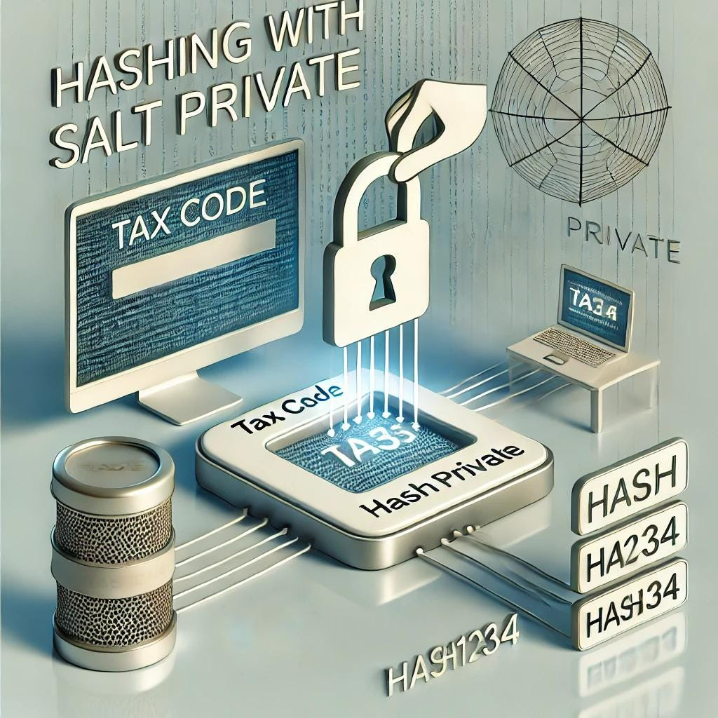

Procedura:

- Aggiungo un salt univoco noto solo al titolare (es. data di nascita o un valore condiviso).
- Applico l’algoritmo di hashing.

```python
import hashlib
def anonimizza_cf(codice_fiscale, salt):
    dato = codice_fiscale + salt
    hash_object = hashlib.sha256(dato.encode())
    return hash_object.hexdigest()
```

## 2.1 Esempio

- codice_fiscale = “RSSMRA80A01H501U”
- salt = “01/01/1980” # Salt privato conosciuto dal titolare
- hash_cf = anonimizza_cf(codice_fiscale, salt)
- Pro: Non è possibile risalire al codice fiscale senza il salt.
- Contro: Il titolare deve conoscere o avere accesso al salt.

# 3 Cifratura Simmetrica

La cifratura simmetrica utilizza un algoritmo come AES per codificare il codice fiscale. Il titolare può decifrare il codice con una chiave segreta condivisa.

Procedura:

- Scelgo un algoritmo di cifratura (es. AES).
- Uso una chiave segreta condivisa (es. una password).
- Cripto il codice fiscale
- Fornisco il dato criptato al titolare.
- Pro: Garantisce riservatezza elevata; solo il titolare con la chiave può decifrare.
- Contro: Il titolare deve conservare la chiave.

```python
from cryptography.fernet import Fernet

# Genera una chiave
key = Fernet.generate_key()

# Crea un oggetto Fernet con la chiave generata
cipher = Fernet(key)

# Codice fiscale da cifrare
codice_fiscale = "RSSMRA80A01H501U"

# Cifra il codice fiscale
encrypted_cf = cipher.encrypt(codice_fiscale.encode())
print("Codice cifrato:", encrypted_cf)

# Decifra il codice fiscale
decrypted_cf = cipher.decrypt(encrypted_cf).decode()
print("Codice decifrato:", decrypted_cf)
```

```
Codice cifrato: b'gAAAAABoztmcJnDuHh7_mF5_RUlaRHZj8SCosa7ryprjIF5tzMv3py7kkirptBAV_ReOhWifE9Bkcf6Xfg62mZIEJm5hHxPBAVn3q9WTLcgiLN_ceEawCuI='
Codice decifrato: RSSMRA80A01H501U
```

## 3.1 Risultato

Eseguendo il codice, otterrai l’output:

```
Codice cifrato: una stringa cifrata in base64 (non leggibile direttamente).
Codice decifrato: il valore originale del codice fiscale (RSSMRA80A01H501U).
```

Note importanti:

```
Gestione della chiave: La chiave generata (key) deve essere conservata in modo sicuro se hai bisogno di decifrare i dati in futuro.
Sicurezza: Non condividere mai la chiave pubblicamente; è fondamentale per mantenere i dati al sicuro.
```

# 4 Sostituzione Parziale

Sostituisco parte del codice fiscale con caratteri generici, mantenendo solo alcune informazioni identificative per il titolare.

## 4.1 Esempio:

```python
def anonimizza_cf_parziale(codice_fiscale):
    """
    Funzione per anonimizzare parzialmente un codice fiscale.
    Mantiene visibili solo i primi 3 caratteri, i caratteri 6 e 7,
    e gli ultimi 4 caratteri.
    """
    return f"{codice_fiscale[:3]}***{codice_fiscale[6:8]}******{codice_fiscale[-4:]}"

# Codice fiscale da anonimizzare
codice_fiscale = "RSSMRA80A01H501U"

# Anonimizzazione parziale
cf_anonimizzato = anonimizza_cf_parziale(codice_fiscale)
print("Codice Fiscale Anonimizzato:", cf_anonimizzato)
```

```
Codice Fiscale Anonimizzato: RSS***80******501U
```

Spiegazione:

```
codice_fiscale[:3]: Prende i primi 3 caratteri.
codice_fiscale[6:8]: Prende i caratteri dalla posizione 6 alla posizione 7 inclusa.
codice_fiscale[-4:]: Prende gli ultimi 4 caratteri.
I caratteri mascherati sono sostituiti da *.
```

# 5 Tokenizzazione

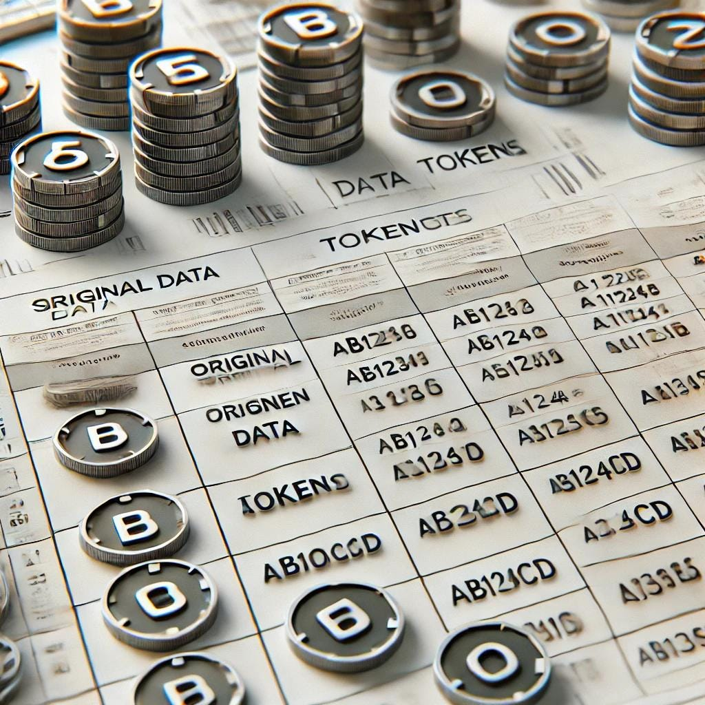

Sostituisco il codice fiscale con un identificatore univoco casuale (token). Solo il titolare o un sistema può ricondurre il token al codice originale.

## 5.1 Esempio:

- Codice fiscale: RSSMRA80A01H501U
- Token: ABC12345XYZ
- Tabella di mapping (conservata separatamente): ABC12345XYZ -> RSSMRA80A01H501U
- Pro: Nessun dato sensibile è esposto.
- Contro: Richiede un sistema per mantenere il mapping.

```python
import uuid

def anonimizza_cf_token(codice_fiscale):
    """
    Funzione per anonimizzare un codice fiscale utilizzando un token UUID.
    """
    # Genera un token unico (primi 8 caratteri di un UUID)
    token = str(uuid.uuid4())[:8]

    # Crea un mapping tra il token e il codice fiscale
    mapping = {token: codice_fiscale}
    print("Mapping (da salvare):", mapping)

    # Ritorna il token
    return token

# Codice fiscale da anonimizzare
codice_fiscale = "RSSMRA80A01H501U"

# Anonimizzazione con token
cf_anonimizzato = anonimizza_cf_token(codice_fiscale)
print("Codice Fiscale Anonimizzato:", cf_anonimizzato)
```

```
Mapping (da salvare): {'727ba438': 'RSSMRA80A01H501U'}
Codice Fiscale Anonimizzato: 727ba438
```

## 5.2 Dettagli:

```
UUID Token: La funzione genera un identificatore unico (uuid.uuid4) e ne utilizza i primi 8 caratteri come token per rappresentare il codice fiscale.
Mapping: Salva il mapping tra il token e il codice fiscale originale. Questo mapping deve essere conservato in modo sicuro (es. database) per consentire una futura deanonimizzazione.
Ritorno: Il token viene restituito come codice anonimo.
```

Nota Importante

```
Il mapping è temporaneo nel codice fornito. Per un'applicazione reale, è essenziale salvare il mapping in un archivio persistente (come un database o un file) per potervi accedere successivamente.
Sicurezza: Considera l'accesso controllato al mapping per prevenire abusi e garantire la privacy degli utenti.
```

## 5.3 Quale tecnica scegliere per pubblicare un elenco di codici fiscali??

Dipende dal contesto:

- Per alta sicurezza: Cifratura simmetrica o hashing con salt.
- Per facilità d’uso: Sostituzione parziale.
- Per sistemi centralizzati: Tokenizzazione.

[figure not shown]

Se il codice fiscale deve essere stampato per il titolare (ad esempio in un report o un documento) occorre considerare contemporaneamente:

- l’interpretabilità per il titolare
- la riservatezza

La Sostituzione Parziale mantiene solo alcune parti identificative del codice fiscale, come le iniziali e un suffisso significativo. Questo metodo è semplice e leggibile (anche dagli altri, però).

Il codice fiscale Anonimizzato con Hashing e Salt Privato utilizza l’hashing per creare un codice unico che il titolare può interpretare solo conoscendo il salt.

- codice_fiscale = “RSSMRA80A01H501U”
- salt = “01/01/1980” # Il salt può essere condiviso solo con il titolare
- Codice Fiscale Anonimizzato: 9F4E8D12

La Cifratura Simmetrica (Stampabile e Decifrabile Solo dal Titolare) produce un codice stampabile e leggibile, decifrabile solo con la chiave privata.

- codice_fiscale = “RSSMRA80A01H501U”
- Codice Fiscale Anonimizzato: gAAAAABlcO9Z8H
- Il titolare può decifrare l’intero codice fiscale utilizzando la chiave segreta.

La Tokenizzazione genera un token casuale per anonimizzare il codice fiscale, con un mapping separato conservato nel sistema.

- codice_fiscale = “RSSMRA80A01H501U”
- cf_anonimizzato = anonimizza_cf_token(codice_fiscale)
- print(“Codice Fiscale Anonimizzato:”, cf_anonimizzato)

Output:

- Mapping (da salvare): {‘1a2b3c4d’: ‘RSSMRA80A01H501U’}
- Codice Fiscale Anonimizzato: 1a2b3c4d

## 5.4 Conclusione

- Leggibile direttamente dal titolare: sostituzione parziale o tokenizzazione.
- Maggiore sicurezza: hashing con salt o cifratura simmetrica.

## 5.5 i codici fiscali delle imprese sono dati sensibili?

Il codice fiscale di un’impresa è considerato un dato personale, ma non rientra nella categoria dei dati sensibili.

Secondo il Regolamento Generale sulla Protezione dei Dati (GDPR), i dati personali sono informazioni che identificano o rendono identificabile una persona fisica, come il nome, l’indirizzo o il codice fiscale.

I dati sensibili, invece, includono informazioni che rivelano l’origine razziale o etnica, le opinioni politiche, le convinzioni religiose o filosofiche, l’appartenenza sindacale, dati genetici, dati biometrici, dati relativi alla salute o alla vita sessuale o all’orientamento sessuale di una persona ([Commissione Europea](https://commission.europa.eu/law/law-topic/data-protection/rules-business-and-organisations/legal-grounds-processing-data/sensitive-data/what-personal-data-considered-sensitive_it))

È importante notare che il codice fiscale di una ditta individuale, essendo associato a una persona giuridica, non è soggetto alle stesse tutele previste per i dati personali delle persone fisiche.

Tuttavia, l’utilizzo del codice fiscale deve avvenire nel rispetto delle normative vigenti in materia di protezione dei dati.

## 5.6 **Come è composto il codice fiscale**

Il codice fiscale italiano è composto da **16 caratteri alfanumerici**, che rappresentano una combinazione di lettere e numeri, e viene calcolato sulla base dei dati anagrafici del soggetto. La sua struttura è la seguente:

## 5.7 1. Cognome (3 lettere)

- Le prime tre lettere sono prese dal cognome:
- Vengono usate le prime tre consonanti.
- Se il cognome ha meno di tre consonanti, si usano le vocali per arrivare a tre lettere.
- Se il cognome ha meno di tre lettere, si aggiunge la lettera “X”.

## 5.8 2. Nome (3 lettere)

- Le successive tre lettere derivano dal nome:
- Si prendono le prime tre consonanti.
- Se il nome ha più di tre consonanti, si prendono la prima, la terza e la quarta.
- Se il nome ha meno di tre consonanti, si completano con le vocali.
- Anche in questo caso, se il nome ha meno di tre lettere, si aggiunge la “X”.

## 5.9 3. Data di nascita e sesso (6 caratteri)

- **Anno di nascita (2 cifre)**: le ultime due cifre dell’anno (es. 1990 → 90).
- **Mese di nascita (1 lettera)**: ogni mese è rappresentato da una lettera:
- Gennaio: A, Febbraio: B, Marzo: C, Aprile: D, Maggio: E, Giugno: H, Luglio: L, Agosto: M, Settembre: P, Ottobre: R, Novembre: S, Dicembre: T.
- **Giorno di nascita e sesso (2 cifre)**:
- Per gli uomini si usa il giorno di nascita (es. 05 → 05).
- Per le donne, al giorno si aggiunge 40 (es. 05 → 45).

## 5.10 4. Comune o Stato estero di nascita (4 caratteri)

- È rappresentato da un codice numerico o alfanumerico, assegnato a ogni comune italiano o stato estero.

## 5.11 5. Carattere di controllo (1 carattere)

- L’ultimo carattere è un **carattere di controllo**, calcolato secondo un algoritmo basato su tutti i caratteri precedenti. Serve a verificare la correttezza del codice fiscale.

## 5.13 La pseudoanomizzazione di **R**M********501Z**

Il punto 4 è una parte “delicata”: i codici dei comuni sono univoci; **non sono univoci** se si rimuove la lettera iniziale e si considerano solo le cifre.

I codici dei comuni italiani sono composti da una **lettera** (che identifica la provincia) seguita da un **numero a tre cifre** (che identifica il comune all’interno della provincia).

Il **codice fiscale contiene il codice catastale** (noto anche come **codice Belfiore**) del luogo di nascita

La combinazione completa (es. “H501” per Roma) è univoca, ma se si considera solo la parte numerica (es. “501”), ci potrebbero essere più comuni con lo stesso numero in province diverse:

- Roma ha il codice **H501**.
- Torino ha il codice **L501**.

Se togliamo la lettera, rimarrebbe solo **501**, che non è più sufficiente per distinguere i comuni.

## 5.14 L’hash di una parola è sempre lo stesso?

| Parola | SHA-256 |
| --- | --- |
| ROSSI | c3ae8397a9b549bcb3f59dac761585227ee3ee6320e4719957a844e35a4ff50e |
| rossi | 30cc6dd8ef8458e679e13ae3bf3f634cace9810e2eea03318b16e011385f93b8 |
| RosSi | 92272e94fa44b8a6eb53d63528b75bf6e7d43f30e2143b2f6523f3c2f94e2b6f |
| roSSi | df37f9bd1129720eb09c8fb2c70201c58612e5546cba99609769e57c03d09a58 |
| ROSSi | 7e88d9c1e14ea00a4e760122d890854d7a7cfd8c95cb3dd85d48d5c9c2536eaa |

Se non altero la parola iniziale ad es con maiuscole/minuscole, punteggiatua iniziale/finale, numeri al posto delle lettere, avrò sempre lo stesso hash - L’hash di una parola è sempre lo stesso se uso lo stesso algoritmo e la stessa parola in input - Se cambio anche solo un carattere (anche la maiuscola/minuscola), l’hash cambia completamente

Se applico una funzione di hash all’intero record (ad esempio `"ROSSI|100|"` e `"ROSSI|200|"`), perdo però la possibilità di fare analisi esplorativa dei dati #EDA sulla prima colonna. Questo perché l’hash trasforma tutto il record in un valore unico e non permette di ricostruire le singole parti.

### 5.14.1 Soluzioni possibili

1. **Hash solo della seconda colonna**
   - Mantengola prima colonna in chiaro per l’EDA e applico l’hash solo alle altre colonne
   - Esempio:

     ```
     | Nome  | Valore Hashato |
     |-------|--------------------------------------------------|
     | ROSSI | dffb7c5d43b1a469f7d1a93c3d4e72af68d83a5b3f401cd7 |
     | ROSSI | a2ef4857c9d2c8b67e2f3a5dbf2b6c1d4e8a9e7c3b01f9a2 |
     ```

2. **Tokenizzazione delle colonne separata**
   - Hash ogni colonna separatamente e poi unisci gli hash.
   - Ad esempio, invece di hashare `"ROSSI|100|"`, faccio

     ```python
     hash1 = hashlib.sha256("ROSSI".encode()).hexdigest()
     hash2 = hashlib.sha256("100".encode()).hexdigest()
     record_hash = f"{hash1}|{hash2}"
     ```

     Così posso ancora analizzare la distribuzione dei nomi.
3. **Usare una funzione hash reversibile per la prima colonna**
   - Se la privacy non è un problema critico, potrei usare una funzione di codifica invece di un hash per la prima colonna (come Base64 o un ID numerico anonimo).
4. **Hash parziale**
   - Se voglio anonimizzare ma mantenere qualche analisi, posso troncare l’hash (ad esempio, usare solo i primi 8 caratteri).

Se l’obiettivo è proteggere i dati mantenendo l’analizzabilità, la scelta migliore è hashare solo le colonne sensibili e lasciare le chiavi utili per l’EDA in chiaro.

Es: una tabella con **10 colonne**, ma solo **5 contengono dati sensibili**

La soluzione migliore per mantenere la possibilità di fare #EDA è **hashare solo le colonne critiche** lasciando in chiaro quelle che servono per l’analisi.

### 5.14.2 **Soluzione consigliata: Hashare solo le colonne sensibili**

1. **Mantieni in chiaro le colonne non sensibili**
   - Es. **Categoria**, **Data**, **Regione**, **Prodotto**, **Quantità**
2. **Hasha le colonne sensibili con SHA-256**
   - Es. **Nome**, **Codice fiscale**, **Email**, **Telefono**, **Indirizzo**
3. **Mantener gli hash separati** per ogni colonna invece di fare un hash dell’intero record.
   - Così si può ancora fare ricerche e raggruppamenti sulle colonne non sensibili.

### 5.14.3 Esempio di implementazione in Python

```python
import pandas as pd
import hashlib

# Simuliamo un dataset con 10 colonne, di cui 5 sensibili

df = pd.DataFrame({
    "ID": [1, 2, 3],
    "Nome": ["Mario Rossi", "Luca Bianchi", "Giulia Verdi"],
    "Codice Fiscale": ["RSSMRA80A01H501Z", "BNCLCU85B12F205X", "VRDGLI90C20H501Z"],
    "Email": ["mario@mail.com", "luca@mail.com", "giulia@mail.com"],
    "Telefono": ["3331234567", "3209876543", "3921112233"],
    "Indirizzo": ["Via Roma 1", "Piazza Duomo 2", "Viale Marconi 3"],
    "Categoria": ["A", "B", "A"],
    "Regione": ["Lombardia", "Lazio", "Toscana"],
    "Prodotto": ["PC", "Tablet", "Smartphone"],
    "Quantità": [10, 5, 8]
})


# Funzione per hashare solo le colonne critiche
def hash_column(value):
    return hashlib.sha256(value.encode()).hexdigest() if pd.notna(value) else value

# Colonne critiche da anonimizzare
columns_to_hash = ["Nome", "Codice Fiscale", "Email", "Telefono", "Indirizzo"]

# Applichiamo l'hashing solo alle colonne sensibili
for col in columns_to_hash:
    df[col] = df[col].astype(str).apply(hash_column)

# Mostrare il dataframe anonimo
import ace_tools as tools
tools.display_dataframe_to_user(name="Tabella anonimizzata", dataframe=df)
```

[output not shown]

### 5.14.4 **Vantaggi di questo approccio**

✅ **EDA è ancora possibile** su **Categoria, Regione, Prodotto, Quantità**  
✅ **Non si può risalire ai dati originali** senza conoscere i valori iniziali  
✅ **Raggruppamenti e analisi sono ancora fattibili** sulle colonne in chiaro  
✅ **Privacy garantita** perché le informazioni sensibili sono criptate

### 5.14.5 **Se devo anche unire dati tra tabelle (Join)**

Se devo fare **join tra dataset** e le colonne sensibili sono chiavi, **uso sempre lo stesso algoritmo di hash**, così l’unione sarà ancora possibile.

Ad esempio, se in due tabelle compare la colonna **Codice Fiscale**, hasho sempre nello stesso modo, così posso ancora unirle.

Ci sono **diversi modi di fare hashing**, a seconda dell’algoritmo e dell’uso specifico. Ecco una panoramica delle principali categorie e algoritmi:

# 6 Funzioni di hash crittografiche 🔒

Queste funzioni sono progettate per essere sicure e resistenti alle collisioni.

| Algoritmo | Output (bit) | Velocità | Sicurezza |
| --- | --- | --- | --- |
| **MD5** | 128 | Veloce 🚀 | Non sicuro ❌ (facili collisioni) |
| **SHA-1** | 160 | Medio ⚡ | Obsoleto ❌ (collisioni trovate) |
| **SHA-256** | 256 | Lento ⏳ | Sicuro ✅ |
| **SHA-512** | 512 | Più lento 🐌 | Molto sicuro ✅✅ |
| **BLAKE2** | Variabile | Veloce 🚀 | Sicuro ✅ |
| **SHA-3** | Variabile | Medio ⚡ | Alternativa moderna ✅ |

## 6.1 📌 **Quando usarli?**

- **SHA-256 o SHA-512** per anonimizzare dati
- **BLAKE2** per efficienza
- **MD5/SHA-1** solo per checksum e NON per sicurezza

# 7 Funzioni hash per password 🔑

Queste funzioni sono progettate per essere lente e resistenti agli attacchi brute-force.

| Algoritmo | Caratteristiche |
| --- | --- |
| **bcrypt** | Lento, con salting, usato in sicurezza |
| **scrypt** | Più resistente a attacchi hardware |
| **PBKDF2** | Sicuro, ma meno efficiente rispetto a bcrypt/scrypt |
| **Argon2** | Il più sicuro oggi, vincitore del PHC (Password Hashing Competition) |

## 7.1 📌 **Quando usarli?**

- **bcrypt/scrypt** per salvare password
- **Argon2** per la massima sicurezza

# 8 Funzioni hash per strutture dati 🗂️

Queste funzioni sono usate in database, tabelle hash e strutture dati.

| Algoritmo | Usi |
| --- | --- |
| **Python `hash()`** | Per dizionari e set, cambia a ogni esecuzione! |
| **MurmurHash** | Veloce e ottimo per database |
| **CityHash / FarmHash** | Ottimizzati per grandi dataset |
| **xxHash** | Molto veloce e leggero |

## 8.1 📌 Quando usarli?

- **Dizionari e database** per indicizzazione veloce
- **Bloom filters** per verifiche rapide

# 9 Hashing non crittografico per compressione 🔄

Questi algoritmi sono usati per ridurre il numero di bit mantenendo una distribuzione uniforme.

| Algoritmo | Usi |
| --- | --- |
| **CRC32** | Controllo errori nei file |
| **Adler-32** | Veloce, ma meno sicuro |
| **FNV-1a** | Usato in alcune tabelle hash |

## 9.1 📌 **Quando usarli?**

- **Checksum su file** (MD5/SHA-1 sono comunque preferibili)
- **Compressione rapida** senza esigenze di sicurezza

# 10 **🛠 Quale usare?**

- **Per proteggere dati sensibili** → SHA-256, SHA-512, BLAKE2
- **Per salvare password** → bcrypt, scrypt, Argon2
- **Per strutture dati e database** → MurmurHash, xxHash
- **Per verificare integrità file** → CRC32, SHA-1

Torna in cima